# Woody encroachment in wetlands

[VAAT-GJEN-01]

Authors

Affiliations

Bendik Sivertsen

Sállir Natur AS

Jesus Adrian Chimal-Ballesteros

Sállir Natur AS

Lasse Keetz

Field Geospatial AS

Published

November 24, 2026

**NoteStatus of this document**

This document follows the structure of NINA’s ecRxiv indicator template. It has **not** been submitted to or published on ecRxiv, and it is not a NINA product. The ecRxiv badges and the ecRxiv citation are therefore left out.

**TipMetadata**

Table 1: Indicator metadata

| Variable | Value |
| --- | --- |
| Indicator ID | VAAT-GJEN-01 |
| Indicator name | Woody encroachment in wetlands |
| Norwegian name | Gjengroing i våtmark |
| Continent | Europe |
| Country | Norway |
| Ecosystem Condition Typology class | B2 - Structural State characteristics |
| Realm | Freshwater-Terrestrial (TF) |
| Biome | TF1 Palustrine wetlands biome |
| Ecosystem | TF1.6 Boreal, temperate and montane peat bogs; TF1.7 Boreal and temperate fens |
| Norwegian ecosystem | Våtmark |
| Year added | 2026 |
| Last update | 2026 |
| Status | complete |
| Version | 000.002 |
| Version comment | Reference at 30 m and sampling at 20 m, as in the original workflow |
| Normalised | Yes |
| Spatial aggregation pathway | Truncate/Scale/Transform (sigmoid) - Aggregate (area-weighted arithmetic mean) |
| Precision | Bootstrap standard error (1000 draws) of the area-weighted mean |

**TipLog**

- 24 Nov. 2026 - First version of this document

## 1. Summary

1. **Background and rationale**: Open wetlands can become overgrown with trees and shrubs (Norwegian: *gjengroing*) after drainage, nutrient input, climate warming or the end of mowing and grazing. The indicator measures how tall the vegetation is, compared with wetland in good condition and with forest.
2. **Methods**: Vegetation height is the difference between the national LiDAR surface and terrain models. It is sampled in mapped wetland (AR5) and scaled between two reference heights for each combination of region and bioclimatic zone: good-condition wetland (X<sub>100</sub>) and forest (X<sub>0</sub>).
3. **Interpretation**: A value of 1 means that the vegetation is no taller than in wetland in good condition. Values decreasing towards 0 mean that the vegetation approaches the height of forest. Vegetation lower than the reference is not counted as a deviation.
4. **Results and development needs**: The national value is 0.949 (n = 20,999 sample cells). It is lowest in Østlandet (0.908) and highest in Nord-Norge (0.977). 87% of the cells score above 0.99, so the indicator mainly separates overgrown cells from the rest. The reference for wetland that naturally has trees needs work, and the uncertainty estimate covers sampling only.

## 2. About the underlying data

- **Elevation**: Kartverket’s national terrain and surface models (DTM1, DOM1), 1 m.
- **Population**: AR5 *myr* (mire).
- **Good-condition reference**: NiN nature-type polygons mapped in wetland with condition “god” (good).
- **Forest reference**: AR5 *skog* (forest), without areas disturbed 1986–2020 (Senf & Seidl, 2021).
- **Other**: bioclimatic zones (open when downloaded 2026-07-20, but the map service was gone on 2026-11-24), building footprints (OpenStreetMap), the SSB 50 km grid, and five regions.

### 2.1 Spatial and temporal resolution and extent

Mainland Norway. The laser scanning was flown between 2010 and 2024, varying by area, and the indicator is a single snapshot. The year label 2024 is the last flight year.

### 2.2 Sampling design

Up to 1000 random points are drawn in AR5 mire in each stratum (region × bioclimatic zone, seed 123). Points on buildings are removed. The same design is used in AR5 forest, where points in disturbed forest are also removed.

### 2.3 Original units

Metres above ground.

### 2.4 Instructions for citing, using and accessing data

All data are open except AR5, which requires access through Norge digitalt. Without AR5, the pipeline uses the open AR50. Sources, versions and download dates are listed in the README.

### 2.5 Additional comments about the dataset

NINA’s original used *Nasjonalt grunnkart* for the population and forest, and FKB buildings. AR5 and OpenStreetMap replace them here.

## 3. Indicator properties

### 3.1 Ecosystem Condition Typology Class (ECT)

B2 - structural state, as in NINA’s NO_GJEN_001: the indicator describes vegetation structure.

### 3.2 Ecosystem condition characteristic

Openness: in good condition, the wetland has few trees.

### 3.3 Collinearities with other indicators

VAAT-GJEN-02 measures the same characteristic with the same references and should not be used together with VAAT-GJEN-01. The light indicator VAAT-FULI-01 may covary.

### 3.4 Impact factors

Drainage, nitrogen deposition and nutrient input, climate warming, and the end of traditional mowing and grazing.

### 3.5 Spatial aggregation

The variable is scaled per 20 × 20 m cell and aggregated as an area-weighted mean per region, 50 km cell and nationally. All cells are the same size, so the regional mean gives each sampled stratum nearly the same weight, regardless of how much wetland the stratum contains.

## 4. Reference condition and levels

### 4.1 Reference condition

Wetland with little or no woody encroachment, under largely intact ecosystems (Nybø & Evju, 2017).

### 4.2 Reference levels

- **X<sub>100</sub>**: the median height of good-condition wetland. The canopy height is averaged to 30 m cells, the median is taken per NiN polygon, and then across polygons in the stratum. Tree-covered swamp, spring and shore forest types are excluded, as in the original.
- **X<sub>0</sub>**: the 90th percentile of forest height in the stratum, read as means of 20 m cells.
- **X<sub>60</sub>**: not defined in the original. The limit 0.6 on the indicator scale is the platform default.

The evaluation scale is part of the definition. At 1 m, an open bog is a few centimetres almost everywhere. A 30 m cell also includes scattered trees and, for small polygons, the forest edge, and gives 5–20 times higher values. The scales follow NINA’s Earth Engine script.

Table 2: Reference heights per stratum, and number of scored cells

| Region | Zone | X100 (m) | X0 (m) | n |
| --- | --- | --- | --- | --- |
| Nord-Norge | Lavalpin sone (LA) | 0.05 | 3.84 | 1,000 |
| Nord-Norge | Mellomboreal sone (MB) | 0.32 | 6.63 | 1,003 |
| Nord-Norge | Nordboreal sone (NB) | 0.31 | 5.82 | 999 |
| Nord-Norge | Sørboreal sone (SB) | 0.17 | 6.99 | 1,000 |
| Midt-Norge | Boreonemoral sone (BN) | 0.04 | 8.51 | 1,000 |
| Midt-Norge | Mellomboreal sone (MB) | 0.59 | 7.73 | 1,003 |
| Midt-Norge | Nordboreal sone (NB) | 0.19 | 6.48 | 999 |
| Midt-Norge | Sørboreal sone (SB) | 0.63 | 9.35 | 1,000 |
| Vestlandet | Boreonemoral sone (BN) | 0.12 | 11.20 | 1,003 |
| Vestlandet | Mellomboreal sone (MB) | 0.30 | 10.12 | 1,001 |
| Vestlandet | Nordboreal sone (NB) | 0.07 | 9.27 | 1,003 |
| Vestlandet | Sørboreal sone (SB) | 0.11 | 10.65 | 1,000 |
| Østlandet | Boreonemoral sone (BN) | 1.56 | 11.33 | 1,000 |
| Østlandet | Lavalpin sone (LA) | 0.11 | 4.85 | 981 |
| Østlandet | Mellomboreal sone (MB) | 0.56 | 10.51 | 1,001 |
| Østlandet | Nordboreal sone (NB) | 0.13 | 6.18 | 1,000 |
| Østlandet | Sørboreal sone (SB) | 1.83 | 11.31 | 1,001 |
| Sørlandet | Boreonemoral sone (BN) | 1.72 | 10.97 | 1,001 |
| Sørlandet | Mellomboreal sone (MB) | 0.88 | 9.59 | 1,002 |
| Sørlandet | Nordboreal sone (NB) | 0.17 | 6.46 | 1,002 |
| Sørlandet | Sørboreal sone (SB) | 1.29 | 9.93 | 1,000 |

#### 4.2.1 Spatial resolution and validity

Reference levels vary by region and bioclimatic zone. 21 of the 25 strata have a good-condition reference; cells in the other four are left out. NINA points out that values scaled against such large areas are not precise for a single polygon and should not be presented at that level.

## 5. Uncertainties

### 5.1 General uncertainties

- **Heights below X<sub>100</sub> are set to X<sub>100</sub>**, as in the original. This applies to 77% of the cells, which therefore score 1. The reported height `v` is the mean after this step.
- **Wetland with trees.** AR5 separates only mire and forest. Naturally wooded wetland can count as overgrown mire, or fall in the forest reference.
- **Deviation from NINA’s reference table.** 15 of 20 strata are within 0.5–2 times the published X<sub>100</sub>. The largest deviations are in Sørlandet (SB, MB) and Nord-Norge (NB), where 65–90% of the polygons were mapped in 2023–2025, after the published table was made.
- **Small reference samples.** Some strata rest on few good-condition polygons (fewest: 11).
- **Condition class.** “God” in NiN is an overall assessment and may reflect factors other than encroachment.

### 5.2 Reported uncertainties

`sd` is the bootstrap standard error (1000 draws) of the area-weighted mean, as in `ecTools::ea_spread`. It is inferential and covers the sample of cells only. It becomes very small with many cells, and does not include uncertainty in the reference heights, which NINA also notes as a weakness.

## 6. References

Moen, A. (1998). *Nasjonalatlas for Norge: Vegetasjon*. Statens kartverk.

Nybø, S., & Evju, M. (Eds.). (2017). *Fagsystem for fastsetting av god økologisk tilstand: Forslag fra et ekspertråd*. Ekspertrådet for økologisk tilstand.

Senf, C., & Seidl, R. (2021). Mapping the forest disturbance regimes of Europe. *Nature Sustainability, 4*(1), 63–70. https://doi.org/10.1038/s41893-020-00609-y

The method follows NINA’s indicator document NO_GJEN_001 by Mienna and Venter.

## 7. Import and prepare datasets

The code in chapters 7, 9 and 11 is read from the scripts in `R/` when this document is rendered. It is shown, but not executed. The results in chapter 10 are read from the files those scripts wrote to `outputs/`. To recalculate everything, run the scripts in the order given in the README.

### 7.1 Regions and bioclimatic strata

```r
# ===========================================================
# STAGE 2: Load the five-region delineation for Norway.
# ===========================================================

regions_path <- file.path(spatial_dir, "regions.shp")
if (!file.exists(regions_path)) {
  stop(
    "Missing required file: ", regions_path, "\n",
    "Copy it from VAAT-FUNC-01/data/NINA/spatial/regions.shp or ",
    "VAAT-CONN-01/data/spatial/regions.shp and re-run."
  )
}

regions <- st_read(regions_path, quiet = TRUE)

# Known double-encoding bug in this file's DBF: ids 3/5 come back garbled.
# Every downstream join matches on the literal region name, so this must
# be fixed here regardless.
regions$region[regions$id == 3] <- "Østlandet"
regions$region[regions$id == 5] <- "Sørlandet"

regions <- regions %>%
  mutate(region = factor(region, levels = regionlvl))


# ===========================================================
# STAGE 3: Bioclimatic zones -> bioClimReg (region x zone strata polygons).
# [OPEN SOURCE] Zones fetched from the public Miljødirektoratet ArcGIS
# service (fetch_bioclim_zones.R) rather than NINA's internal R: drive copy.
# ===========================================================

bioclimzone_path <- file.path(spatial_dir, "bioclim", "bioclimzone.shp")
soner_path       <- file.path(spatial_dir, "bioclim", "soner2017.shp")

if (file.exists(bioclimzone_path)) {
  # Already-dissolved cache: one polygon per zone, NAVN/KLASSE already set.
  bioclim <- st_read(bioclimzone_path, quiet = TRUE) %>%
    st_transform(st_crs(regions))
  bioclim$NAVN <- factor(bioclim$NAVN, levels = vegclimzonelvl)

} else if (file.exists(soner_path)) {
  # Raw tiled source: dissolve by zone name, then assign a numeric class.
  bioclim <- st_read(soner_path, quiet = TRUE) %>%
    st_transform(st_crs(regions))
  bioclim <- bioclim %>%
    group_by(Sone_navn) %>%
    summarise(geometry = st_union(geometry)) %>%
    mutate(KLASSE = as.numeric(as.factor(Sone_navn))) %>%
    rename(NAVN = Sone_navn)
  bioclim$NAVN <- factor(bioclim$NAVN, levels = vegclimzonelvl)

} else {
  stop(
    "Missing required file: ", soner_path, "\n",
    "Run fetch_bioclim_zones.R to produce it."
  )
}

# Intersect zones with regions -> one polygon per unique region x
# bioclim-zone stratum (a "homogeneous ecosystem area"). Everything below
# is stratified against this.
bioClimReg <- bioclim %>%
  st_intersection(regions) %>%
  mutate(vegClimZoneLab = NAVN) %>%
  dplyr::select(region, vegClimZoneLab) %>%
  rowid_to_column("ID")

bioClimReg$vegClimZoneLab <- factor(bioClimReg$vegClimZoneLab, levels = vegclimzonelvl)
bioClimReg$region         <- factor(bioClimReg$region,         levels = regionlvl)
```

### 7.2 Sampling engine: canopy height at points

```r
# ===========================================================
# STAGE 1b: Shared CHM-sampling engine (elevation provider, building
# filter, stratified sampling + extraction) - used by Stage 4/5/6 below.
# Consolidated from 3 originally-separate files (see header) - no
# behavior change, just inlined in dependency order.
# ===========================================================

# --- Elevation provider: DTM/DSM -> CHM (originally
# elevation_source.R). get_chm(aoi) is the documented public interface,
# reading Kartverket's open 1m DTM1/DOM1 tiles directly over HTTP; the
# bulk national sampling below re-derives tile URLs itself in
# .process_tile() rather than calling get_chm() per point, for
# performance, but get_chm() is kept as the documented single-AOI entry
# point. ---

.kartverket_tile_url <- function(tile_id, product) {
  paste0("/vsicurl/https://nedlasting.geonorge.no/hoydedata/", product, "/", tile_id, ".tif")
}

.kartverket_tiles_for_aoi <- function(aoi, tile_footprint_path) {
  tiles <- st_read(tile_footprint_path, quiet = TRUE)
  tiles <- st_transform(tiles, st_crs(aoi))
  hits <- tiles[st_intersects(tiles, aoi, sparse = FALSE)[, 1], ]
  if (nrow(hits) == 0) {
    stop("No DTM1/DOM1 tile covers this area of interest - either it's ",
         "outside Norway or outside Kartverket's current 1m LiDAR coverage. ",
         "Consider the 10m DTM10/DOM10 product (confirmed fully nationwide) ",
         "as a coarser fallback.")
  }
  hits
}

.mosaic_if_needed <- function(rasters) {
  if (length(rasters) == 1) return(rasters[[1]])
  do.call(terra::mosaic, rasters)
}

get_chm_kartverket <- function(aoi,
                                tile_footprint_path = file.path("..", "data", "OpenS_data", "dtm1_tile_footprint.gpkg"),
                                buffer_m = 20) {
  aoi_b <- st_buffer(aoi, buffer_m)
  tiles <- .kartverket_tiles_for_aoi(aoi_b, tile_footprint_path)

  dtm_rasters <- lapply(tiles$tile_id, function(id) terra::rast(.kartverket_tile_url(id, "DTM1")))
  dom_rasters <- lapply(tiles$tile_id, function(id) terra::rast(.kartverket_tile_url(id, "DOM1")))

  dtm <- .mosaic_if_needed(dtm_rasters)
  dom <- .mosaic_if_needed(dom_rasters)

  bbox <- st_bbox(aoi_b)
  win  <- terra::ext(bbox["xmin"], bbox["xmax"], bbox["ymin"], bbox["ymax"])
  dtm_c <- terra::crop(dtm, win)
  dom_c <- terra::crop(dom, win)

  chm <- dom_c - dtm_c
  chm[chm < 0] <- 0
  names(chm) <- "chm"
  chm
}

#' Get a canopy height model (CHM) raster for an area of interest.
#' Reads Kartverket's open 1m DTM1/DOM1 tiles directly over HTTP.
#' @param aoi sf polygon(s), any CRS (reprojected internally as needed).
#' @param buffer_m buffer applied to the AOI before reading. Default 20m.
get_chm <- function(aoi, buffer_m = 20) {
  get_chm_kartverket(aoi, buffer_m = buffer_m)
}

# --- Building filter: drop sample points that fall on a building
# (originally building_mask.R). OSM (open, in use) vs. FKB-Bygning
# (gated, not available - errors immediately if selected). ---

.query_buildings_osm <- function(bbox, buildings_path) {
  wkt <- sf::st_as_text(sf::st_as_sfc(bbox))
  st_read(buildings_path, wkt_filter = wkt, quiet = TRUE)
}

.query_buildings_fkb <- function(bbox, buildings_path) {
  stop("FKB-Bygning source not available - requires Norge Digitalt access. ",
       "Use source = \"osm\" (default), the currently available option.")
}

#' Drop any sample point that falls within a building footprint.
#' @param points_sf sf points, any CRS.
#' @param source "osm" (open, default) or "fkb" (not available - errors
#'   immediately, before any tile is queried).
#' @param tile_footprint_path DTM1 tile grid, reused only as a spatial
#'   batching unit (nothing to do with elevation here).
#' @param buildings_path national building-footprint layer for `source`.
filter_building_points <- function(points_sf,
                                    source = c("osm", "fkb"),
                                    tile_footprint_path = file.path("..", "data", "OpenS_data", "dtm1_tile_footprint.gpkg"),
                                    buildings_path = file.path("..", "data", "OpenS_data", "osm_buildings_national.gpkg")) {
  source <- match.arg(source)
  if (source == "fkb") {
    .query_buildings_fkb(NULL, NULL)  # errors immediately - not implemented
  }

  tiles <- st_read(tile_footprint_path, quiet = TRUE)
  pts <- st_transform(points_sf, st_crs(tiles))
  # Stable row id, independent of row position/count - st_join can
  # duplicate a row when a point falls in the (small) overlap between
  # adjacent DTM1 tile footprints, so a position-based index back into
  # points_sf would silently corrupt results (a logical vector longer
  # than nrow(points_sf) appends phantom NA-geometry rows rather than
  # erroring - confirmed the hard way originally).
  pts$.row_id <- seq_len(nrow(pts))
  joined <- st_join(pts, tiles["tile_id"])
  tile_ids <- unique(joined$tile_id)
  tile_ids <- tile_ids[!is.na(tile_ids)]

  cat("Building filter: checking", nrow(pts), "points (", nrow(joined), "after tile join) across",
      length(tile_ids), "tile extents against", basename(buildings_path), "(source:", source, ")...\n")

  on_building_ids <- integer(0)

  for (tid in tile_ids) {
    sub_pts <- joined[joined$tile_id == tid, ]
    bbox <- st_bbox(st_buffer(sub_pts, 20))
    bld <- .query_buildings_osm(bbox, buildings_path)
    if (nrow(bld) == 0) next
    bld <- st_transform(bld, st_crs(tiles))
    hits <- lengths(st_intersects(sub_pts, bld)) > 0
    on_building_ids <- c(on_building_ids, sub_pts$.row_id[hits])
  }

  on_building_ids <- unique(on_building_ids)
  cat("Building filter: dropping", length(on_building_ids), "/", nrow(points_sf),
      "points that fall on a building footprint\n")
  # NOTE: `points_sf[-integer(0), ]` returns ZERO rows, not "all rows" -
  # R's negative indexing does not treat an empty exclusion vector as
  # "exclude nothing". Must special-case it explicitly.
  if (length(on_building_ids) == 0) return(points_sf)
  points_sf[-on_building_ids, ]
}
```

```r
# --- Stratified sampling + tile-batched CHM extraction (originally
# stratified_chm_sampling.R). Mirrors the public sibling
# Gjengroing_GEE_Script.js's stratifiedSample(scale:5, numPoints:1000,
# seed:123), stratified against bioClimReg (region x bioclim, 25 cells)
# to match the vegClimZone column present in NINA's own cached CSVs. ---

# Without these, a stalled/slow remote request can hang indefinitely -
# GDAL's vsicurl has no default timeout. Set before makeCluster() so
# PSOCK workers (which inherit the parent process's environment) pick
# these up too.
Sys.setenv(
  GDAL_HTTP_TIMEOUT        = "15",  # give up on a single request after 15s
  GDAL_HTTP_CONNECTTIMEOUT = "10",
  GDAL_HTTP_MAX_RETRY      = "2",
  GDAL_HTTP_RETRY_DELAY    = "1"
)

#' Split polygons at bioClimReg strata boundaries, tagging each fragment
#' with its stratum's region/vegClimZoneLab/ID.
assign_to_strata <- function(polygons, bio_clim_reg) {
  polygons <- st_transform(polygons, st_crs(bio_clim_reg)) %>% st_make_valid()
  suppressWarnings(st_intersection(polygons, bio_clim_reg))
}

#' Draw n_per_stratum stratified random points from `frags` (the output
#' of assign_to_strata), one stratum at a time, area-weighted within
#' each stratum (st_sample's default behaviour across multiple polygons).
draw_stratified_points <- function(frags, n_per_stratum = 1000, seed = 123) {
  set.seed(seed)
  strata_ids <- sort(unique(frags$ID))
  pts_list <- vector("list", length(strata_ids))

  for (i in seq_along(strata_ids)) {
    sid <- strata_ids[i]
    sub <- frags[frags$ID == sid, ]
    total_area <- sum(as.numeric(st_area(sub)))
    if (total_area <= 0 || nrow(sub) == 0) next

    cat("  starting stratum", sid, "(", as.character(sub$region[1]), "/", as.character(sub$vegClimZoneLab[1]), ") -",
        nrow(sub), "polygons,", round(total_area / 1e6, 1), "km^2...\n")
    flush.console()
    t0 <- Sys.time()
    pts <- suppressMessages(st_sample(sub, size = n_per_stratum, type = "random"))
    dt <- round(as.numeric(Sys.time() - t0), 1)
    if (length(pts) == 0) next

    pts_sf <- st_sf(
      stratum_ID     = sid,
      region         = sub$region[1],
      vegClimZoneLab = sub$vegClimZoneLab[1],
      geometry       = pts
    )
    pts_list[[i]] <- pts_sf
    cat("  stratum", sid, "(", as.character(sub$region[1]), "/", as.character(sub$vegClimZoneLab[1]), "):",
        length(pts), "points drawn from", round(total_area / 1e6, 1), "km^2 in", dt, "sec\n")
    flush.console()
  }

  do.call(rbind, pts_list[!sapply(pts_list, is.null)])
}

#' Drop any sample point that falls on a pixel with a recorded
#' disturbance (clear-cut) between 1986-2020, per the Senf et al.
#' disturbance map - used for Stage 4's forest reference-height
#' sampling only (wetlands aren't clear-cut masked in the original
#' methodology). NA in the disturbance raster = no disturbance recorded
#' = keep the point. A valid year (1986-2020) = disturbed = drop.
filter_disturbed_points <- function(points_sf,
                                     disturbance_path = file.path("..", "data", "OpenS_data", "disturbance", "disturbance_year_1986-2020_norway.tif")) {
  dist_r <- terra::rast(disturbance_path)
  pts_proj <- st_transform(points_sf, terra::crs(dist_r))
  vals <- terra::extract(dist_r, terra::vect(pts_proj))
  disturbed <- !is.na(vals[[2]])
  cat("Disturbance filter: dropping", sum(disturbed), "/", nrow(points_sf),
      "points that fall on a recorded 1986-2020 clear-cut\n")
  points_sf[!disturbed, ]
}

#' Per-tile worker: opens one tile's DTM1/DOM1 ONCE (cheap - lazy
#' handles, headers only), then crops/extracts PER POINT with a small,
#' fixed-size window, reusing those handles across every point sharing
#' this tile. Self-contained (re-derives the tile URL inline) so it can
#' run on a parallel worker process without needing anything else
#' sourced there - only `terra` needs to be loaded on each worker.
#' Per-point windows, not one crop spanning all of a tile's points -
#' measured directly: a single bbox spanning many scattered points
#' within a tile balloons back toward a near-full-tile read once
#' points/tile rises much past ~2.
# cell_m > 0: read the origin-anchored cell of size cell_m that CONTAINS
# the point, instead of a buffer window around it. The DTM1 grid is
# integer-aligned in EPSG:25833, so floor(x / cell_m) * cell_m reproduces
# the same global grid Earth Engine uses for scale = cell_m.
# cell_stat: "cell_mean"   = mean of the RAW DOM-DTM over the cell, clamped
#                            at 0 afterwards - what a mean-pyramid read at
#                            that scale gives (the forest anchor, X0);
#            "cell_median" = median of the clamped 1 m CHM over the cell -
#                            an explicit reduceResolution(median) (the
#                            wetland population sample);
#            "window_mean" = the original 1 m behaviour (5 m window).
.process_tile <- function(item, buffer_m, cell_m = 0, cell_stat = "window_mean") {
  tile_url <- function(tile_id, product) {
    paste0("/vsicurl/https://nedlasting.geonorge.no/hoydedata/", product, "/", tile_id, ".tif")
  }
  dtm <- tryCatch(terra::rast(tile_url(item$tile_id, "DTM1")), error = function(e) NULL)
  dom <- tryCatch(terra::rast(tile_url(item$tile_id, "DOM1")), error = function(e) NULL)
  if (is.null(dtm) || is.null(dom)) {
    return(data.frame(row_idx = item$row_idx, chm = NA_real_))
  }

  vals <- numeric(length(item$row_idx))
  for (k in seq_along(item$row_idx)) {
    if (cell_m > 0) {
      x0 <- floor(item$x[k] / cell_m) * cell_m
      y0 <- floor(item$y[k] / cell_m) * cell_m
      win <- terra::ext(x0, x0 + cell_m, y0, y0 + cell_m)
    } else {
      win <- terra::ext(item$x[k] - buffer_m, item$x[k] + buffer_m,
                        item$y[k] - buffer_m, item$y[k] + buffer_m)
    }
    vals[k] <- tryCatch({
      dtm_c <- terra::crop(dtm, win)
      dom_c <- terra::crop(dom, win)
      raw <- dom_c - dtm_c
      if (cell_stat == "cell_mean") {
        max(0, as.numeric(terra::global(raw, "mean", na.rm = TRUE)[1, 1]))
      } else {
        c <- raw; c[c < 0] <- 0
        if (cell_stat == "cell_median") {
          as.numeric(stats::median(terra::values(c), na.rm = TRUE))
        } else {
          as.numeric(terra::global(c, "mean", na.rm = TRUE)[1, 1])
        }
      }
    }, error = function(e) NA_real_)
  }
  data.frame(row_idx = item$row_idx, chm = vals)
}
```

```r
#' Extract mean CHM within a small buffer around each point,
#' tile-batched and parallelized across tiles (network-latency bound,
#' not CPU bound - n_workers=8 is a deliberately moderate choice, not
#' maxed out, to stay considerate to Kartverket's public server).
#' buffer_m = 2.5 -> a 5m-diameter window, mirroring the original
#' script's scale:5 sampling resolution.
extract_chm_at_points <- function(points_sf, buffer_m = 2.5, cell_m = 0, cell_stat = "window_mean",
                                   tile_footprint_path = file.path("..", "data", "OpenS_data", "dtm1_tile_footprint.gpkg"),
                                   n_workers = 8) {
  tiles <- st_read(tile_footprint_path, quiet = TRUE)
  points_sf <- st_transform(points_sf, st_crs(tiles))
  joined <- st_join(points_sf, tiles["tile_id"])
  joined$chm <- NA_real_

  tile_ids <- unique(joined$tile_id)
  tile_ids <- tile_ids[!is.na(tile_ids)]
  cat("Extracting CHM across", length(tile_ids), "distinct DTM1 tiles for", nrow(joined),
      "points (", n_workers, "parallel workers)...\n")

  coords <- st_coordinates(joined)
  work_items <- lapply(tile_ids, function(tid) {
    idx <- which(joined$tile_id == tid)
    list(tile_id = tid, row_idx = idx, x = coords[idx, 1], y = coords[idx, 2])
  })

  cl <- parallel::makeCluster(n_workers)
  on.exit(parallel::stopCluster(cl), add = TRUE)
  parallel::clusterEvalQ(cl, {
    Sys.setenv(GDAL_HTTP_TIMEOUT = "15", GDAL_HTTP_CONNECTTIMEOUT = "10",
               GDAL_HTTP_MAX_RETRY = "2", GDAL_HTTP_RETRY_DELAY = "1")
    library(terra)
  })

  t0 <- Sys.time()
  results_list <- parallel::parLapply(cl, work_items, .process_tile, buffer_m = buffer_m, cell_m = cell_m, cell_stat = cell_stat)
  cat("  extraction across", length(tile_ids), "tiles took",
      round(as.numeric(Sys.time() - t0), 1), "sec\n")

  results_df <- do.call(rbind, results_list)
  joined$chm[results_df$row_idx] <- results_df$chm
  joined
}

#' Top-level entry point: polygons in, stratified+tile-batched CHM
#' samples out. Building-masked by default (source = "osm") before CHM
#' extraction, so sampled heights reflect vegetation, not rooftops.
sample_chm_by_stratum <- function(polygons, bio_clim_reg, n_per_stratum = 1000,
                                   cell_m = 0, cell_stat = "window_mean",
                                   seed = 123, buffer_m = 2.5, n_workers = 8,
                                   filter_buildings = TRUE, building_source = "osm") {
  cat("Assigning", nrow(polygons), "polygons to", nrow(bio_clim_reg), "strata...\n")
  frags <- assign_to_strata(polygons, bio_clim_reg)
  cat("Drawing", n_per_stratum, "points per stratum (seed", seed, ")...\n")
  pts <- draw_stratified_points(frags, n_per_stratum = n_per_stratum, seed = seed)
  cat("Total points drawn:", nrow(pts), "\n")
  if (filter_buildings) {
    pts <- filter_building_points(pts, source = building_source)
    cat("Points remaining after building filter:", nrow(pts), "\n")
  }
  extract_chm_at_points(pts, buffer_m = buffer_m, n_workers = n_workers,
                        cell_m = cell_m, cell_stat = cell_stat)
}
```

### 7.3 Good-condition reference at 30 m

```r
# ============================================================
# Build the wetland reference heights (Stage 5 input of R/):
# one "good condition" canopy-height reference per region x
# bioclimatic-zone stratum, evaluated at 30 m.
#
# METHOD
# The original indicator derives this table in Google Earth Engine as one
# median per good-condition NiN wetland polygon, with the canopy height
# model (CHM = DSM - DTM, 1 m LiDAR) requested at a 30 m scale
# (reduceRegions, median reducer, scale 30), then a median across polygons
# within each stratum. Requesting a computed 1 m image at 30 m makes Earth
# Engine read the DSM and DTM through their mean pyramids, so each 30 m
# value is the mean of the raw 1 m difference over that 900 m^2 cell, with
# the "no negative heights" clamp applied afterwards. This script
# reproduces that evaluation explicitly with open data:
#
#   1. good-condition NiN wetland polygons (R/fetch_nin_data.R), with
#      the same nature-type exclusions the original applies (types that
#      are tree-covered while in good condition) and no T1 mapping units;
#   2. Kartverket DTM1/DOM1 tiles read over HTTP; for each polygon the raw
#      DOM - DTM difference is averaged onto a 30 m grid anchored at the
#      EPSG:25833 origin (the same grid a scale-30 request produces), then
#      clamped at 0;
#   3. per polygon: the median over those 30 m cells, each cell weighted
#      by the fraction of it the polygon covers (Earth Engine's median
#      reducer is coverage-weighted);
#   4. per stratum: the median across polygons.
#
# WHY 30 m MATTERS
# Evaluated at the native 1 m, a good-condition open bog has a median
# height of a few centimetres - almost every pixel is ground. At 30 m each
# cell is a 900 m^2 average that includes scattered trees and, for the
# typically sub-hectare NiN polygons, the surrounding forest edge. The
# same polygons therefore give reference values roughly 5-20x higher at
# 30 m than at 1 m. The 1 m point-sampling reconstruction this repo used
# before (still available in R/ as the "1m" variant) is what produced
# the previously documented 2-16x shortfall against the published
# reference table; the 30 m evaluation removes it (see COMPARISON).
#
# The evaluation scale is a property of the reference definition, not a
# resolution choice made here: the "good condition" anchor is defined as
# a 30 m median, and the population and forest anchors have their own
# scales (20 m) in the original design. Changing any of them changes the
# indicator's meaning.
#
# COMPARISON (optional, printed at the end)
# If the published reference table is available it is joined per stratum.
# It is looked for at ../data/OpenS_data/refvaatmark_published.csv and,
# failing that, downloaded from the indicator's ecRxiv page
# (github.com/NINAnor/ecRxiv, indicators/NO_GJEN_001/data/refvaatmark.csv).
# Full national build (8,200 polygons, 2026-09): 15 of 20 strata within
# 0.5-2x of the published values (4 of 20 at 1 m); the strata that were
# 10-16x low at 1 m agree within 1.05-1.55x. The remaining outliers
# (Sørlandet SB/MB, Nord-Norge NB) are polygon-set differences, not
# method: 65-90 % of those strata's polygons in the current NiN download
# were mapped in 2023-2025 and postdate the polygon set the published
# table was built from. The current NiN download is the correct input for
# a current reconstruction; the published table is not treated as ground
# truth.
#
# RUN
#   Rscript build_refvaatmark_30m.R            full build (default)
#   REF30_N_PER_STRATUM=40  ...                quick validation subsample
#   REF30_N_WORKERS=4       ...                parallel workers (default 4)
# Network-bound (HTTP range reads of DTM1/DOM1), ~40 min nationally with
# 4 workers. Checkpointed per chunk of tiles and resumable: re-running
# skips tiles already in the per-polygon file.
#
# OUTPUT  ../data/OpenS_data/refvaatmark_30m/
#   refvaatmark_30m.csv             region, vegClimZoneLab, ref (m), n,
#                                   plus ref_1m and ref_median30 for
#                                   reference (see column notes below)
#   refvaatmark_30m_perpolygon.csv  per-polygon values (resume checkpoint)
#   refvaatmark_30m_comparison.csv  join to the published table, if found
#
# Column notes: `ref` is the value R/ uses (mean-pyramid 30 m,
# coverage-weighted median). `ref_1m` is the native-resolution zonal
# median of the same polygons and `ref_median30` a median-pyramid variant;
# both are kept only so the scale effect is visible in one table.
# ============================================================

library(sf)
library(terra)
library(dplyr)
library(readr)
library(tibble)

if (requireNamespace("rstudioapi", quietly = TRUE) && rstudioapi::isAvailable()) {
  setwd(dirname(rstudioapi::getActiveDocumentContext()$path))
} else {
  cmd_args   <- commandArgs(trailingOnly = FALSE)
  file_match <- grep("^--file=", cmd_args)
  tried <- tryCatch({
    if (length(file_match) > 0) {
      setwd(dirname(normalizePath(sub("^--file=", "", cmd_args[file_match]))))
    } else {
      setwd(dirname(sys.frame(1)$ofile))
    }
    TRUE
  }, error = function(e) FALSE)
  if (!tried) message("Note: keeping current working directory (", getwd(), ").")
}
# All relative paths below are anchored to: VAAT-GJEN-01/R/

Sys.setenv(
  GDAL_HTTP_TIMEOUT            = "15",
  GDAL_HTTP_CONNECTTIMEOUT     = "10",
  GDAL_HTTP_MAX_RETRY          = "2",
  GDAL_HTTP_RETRY_DELAY        = "1",
  GDAL_DISABLE_READDIR_ON_OPEN = "EMPTY_DIR"
)

n_per_stratum <- suppressWarnings(as.integer(Sys.getenv("REF30_N_PER_STRATUM", "0")))
if (is.na(n_per_stratum)) n_per_stratum <- 0L
n_workers <- suppressWarnings(as.integer(Sys.getenv("REF30_N_WORKERS", "4")))
if (is.na(n_workers) || n_workers < 1) n_workers <- 4L
tag <- if (n_per_stratum > 0) paste0("_TEST", n_per_stratum) else ""
SCALE_M <- 30

data_dir <- file.path("..", "data", "OpenS_data")
out_dir  <- file.path(data_dir, "refvaatmark_30m")
dir.create(out_dir, showWarnings = FALSE, recursive = TRUE)
gdb_path            <- file.path(data_dir, "nin_data", "Naturtyper_nin_0000_norge_4326_FILEGDB.gdb")
tile_footprint_path <- file.path(data_dir, "dtm1_tile_footprint.gpkg")
published_ref_path  <- file.path(data_dir, "refvaatmark_published.csv")
published_ref_url   <- "https://raw.githubusercontent.com/NINAnor/ecRxiv/main/indicators/NO_GJEN_001/data/refvaatmark.csv"
checkpoint_path     <- file.path(out_dir, paste0("refvaatmark_30m_perpolygon", tag, ".csv"))
final_output_path   <- file.path(out_dir, paste0("refvaatmark_30m", tag, ".csv"))
comparison_path     <- file.path(out_dir, paste0("refvaatmark_30m_comparison", tag, ".csv"))
```

```r
if (!file.exists(gdb_path)) {
  stop("Missing required file: ", gdb_path, "\nRun fetch_nin_data.R first to produce it.")
}
if (!file.exists(tile_footprint_path)) {
  stop("Missing required file: ", tile_footprint_path,
       "\nRun build_ar50_wetland_lidar_coverage.R first to produce it.")
}

cat("Mode:", if (n_per_stratum > 0) paste("VALIDATION -", n_per_stratum, "polygons/stratum") else "FULL national build",
    "| workers:", n_workers, "\n")

# --- Strata: region x bioclimatic zone, built exactly as R/ Stage 2-3 ---
regionlvl      <- c("Nord-Norge", "Midt-Norge", "Vestlandet", "Østlandet", "Sørlandet")
vegclimzonelvl <- c("Lavalpin sone (LA)", "Nordboreal sone (NB)", "Mellomboreal sone (MB)",
                    "Sørboreal sone (SB)", "Boreonemoral sone (BN)")

regions_path <- file.path(data_dir, "regions.shp")
if (!file.exists(regions_path)) stop("Missing required file: ", regions_path)
regions <- st_read(regions_path, quiet = TRUE)
# Same DBF double-encoding fix as R/ (ids 3/5 come back garbled).
regions$region[regions$id == 3] <- "Østlandet"
regions$region[regions$id == 5] <- "Sørlandet"
regions$region <- factor(regions$region, levels = regionlvl)

bioclimzone_path <- file.path(data_dir, "bioclim", "bioclimzone.shp")
soner_path       <- file.path(data_dir, "bioclim", "soner2017.shp")
if (file.exists(bioclimzone_path)) {
  bioclim <- st_read(bioclimzone_path, quiet = TRUE) %>% st_transform(st_crs(regions))
} else if (file.exists(soner_path)) {
  bioclim <- st_read(soner_path, quiet = TRUE) %>%
    st_transform(st_crs(regions)) %>%
    group_by(Sone_navn) %>%
    summarise(geometry = st_union(geometry)) %>%
    mutate(KLASSE = as.numeric(as.factor(Sone_navn))) %>%
    rename(NAVN = Sone_navn)
} else {
  stop("Missing required file: ", soner_path, "
Run fetch_bioclim_zones.R to produce it.")
}
bioclim$NAVN <- factor(bioclim$NAVN, levels = vegclimzonelvl)

bio_clim_reg <- bioclim %>%
  st_intersection(regions) %>%
  mutate(vegClimZoneLab = NAVN) %>%
  dplyr::select(region, vegClimZoneLab) %>%
  tibble::rowid_to_column("ID")

tiles <- st_read(tile_footprint_path, quiet = TRUE)

cat("Loading national NiN dataset...\n")
nin <- st_read(gdb_path, layer = "naturtyper_nin_omr", quiet = TRUE)

# Nature types that can be in good condition while tree-covered (swamp,
# spring and strand forests) or that sit on unstable/sloped ground - the
# same exclusion list R/ Stage 5 applies for the 1 m variant.
excluded_naturtyper <- c(
  "Hule eiker", "Hagemark", "Lauveng",
  "Saltpåvirket strand- og sumpskogsmark", "Flommyr, myrkant og myrskogsmark",
  "Grankildeskog", "Sørlig kaldkilde", "Kaldkilde under skoggrensa",
  "Svak kilde og kildeskogsmark", "Varmekjær kildelauvskog",
  "Gammel fattig sumpskog", "Rik gransumpskog", "Rik svartorsumpskog",
  "Kilde-edellauvskog", "Rik gråorsumpskog", "Kalkrik myr- og sumpskogsmark",
  "Rik vierstrandskog", "Rik svartorstrandskog", "Saltpåvirket svartorstrandskog",
  "Leirravine", "Kalkrik helofyttsump",
  "Grotte", "Silt og leirskred", "Fossepåvirket berg"
)

nin_wetland_ref <- nin %>%
  filter(hovedøkosystem == "våtmark") %>%
  filter(tilstand == "god") %>%                    # lowercase in this download
  filter(!(naturtype %in% excluded_naturtyper)) %>%
  filter(!grepl("T1-", ninKartleggingsenheter)) %>%  # values are "NA_T1-..." - no anchor
  st_transform(st_crs(bio_clim_reg)) %>%
  st_make_valid()

cat("Good-condition NiN wetland reference polygons (post-exclusions):",
    nrow(nin_wetland_ref), "\n")

# Largest-overlap stratum assignment (polygons are small, mostly < 1 ha).
frags <- nin_wetland_ref %>%
  st_join(bio_clim_reg %>% select(ID, region, vegClimZoneLab), largest = TRUE) %>%
  filter(!is.na(ID))
# poly_id is assigned before any subsampling so ids are identical between
# validation and full runs.
frags$poly_id <- seq_len(nrow(frags))
cat("Polygons matched to a stratum:", nrow(frags), "/", nrow(nin_wetland_ref), "\n")

if (n_per_stratum > 0) {
  set.seed(123)
  keep <- frags %>%
    st_drop_geometry() %>%
    group_by(ID) %>%
    slice_sample(n = n_per_stratum) %>%
    ungroup() %>%
    pull(poly_id)
  frags <- frags[frags$poly_id %in% keep, ]
  cat("Validation subsample:", nrow(frags), "polygons across",
      n_distinct(frags$ID), "strata\n")
}

# Tile assignment via centroid (safe for sub-hectare polygons).
polys_proj <- st_transform(frags, st_crs(tiles))
centroids  <- st_centroid(st_geometry(polys_proj))
tile_join  <- st_join(st_sf(poly_id = polys_proj$poly_id, geometry = centroids), tiles["tile_id"])
polys_proj$tile_id <- tile_join$tile_id[match(polys_proj$poly_id, tile_join$poly_id)]

n_no_tile <- sum(is.na(polys_proj$tile_id))
cat("Polygons with no matching DTM1 tile (dropped):", n_no_tile, "\n")
polys_proj <- polys_proj[!is.na(polys_proj$tile_id), ]

# Flatten to WKT + plain attributes: terra objects wrap external pointers
# and cannot be passed to parallel workers; rebuild inside each worker.
polys_flat <- polys_proj %>%
  st_drop_geometry() %>%
  select(poly_id, tile_id, region, vegClimZoneLab)
polys_flat$wkt <- sf::st_as_text(sf::st_geometry(polys_proj))
crs_wkt <- sf::st_crs(polys_proj)$wkt

tile_ids <- unique(polys_flat$tile_id)
cat("Distinct DTM1 tiles needed:", length(tile_ids), "\n")

# --- Checkpoint: skip tiles completed in a previous (interrupted) run ---
empty_row <- data.frame(poly_id = integer(), tile_id = character(),
                        med_1m = double(), med_mean30 = double(), med_median30 = double(),
                        n_px_1m = integer(), n_cells_30m = integer(), w_cells_30m = double())
done_tiles <- character(0)
if (file.exists(checkpoint_path)) {
  prev <- read_csv(checkpoint_path, show_col_types = FALSE)
  done_tiles <- unique(prev$tile_id)
  cat("Resuming from checkpoint:", length(done_tiles), "tiles already completed\n")
} else {
  write_csv(empty_row, checkpoint_path)
}
remaining_tiles <- setdiff(tile_ids, done_tiles)
cat("Tiles remaining to process:", length(remaining_tiles), "/", length(tile_ids), "\n")

# Coverage-weighted median: the value at which the cumulative weight first
# reaches half the total.
weighted_median <- function(x, w) {
  ok <- !is.na(x) & !is.na(w) & w > 0
  x <- x[ok]; w <- w[ok]
  if (length(x) == 0) return(NA_real_)
  o <- order(x); x <- x[o]; w <- w[o]
  cw <- cumsum(w) / sum(w)
  x[which(cw >= 0.5)[1]]
}
```

```r
process_tile_zonal_30m <- function(tid, polys_flat, crs_wkt, scale_m, weighted_median) {
  sub <- polys_flat[polys_flat$tile_id == tid, ]
  na_row <- function(pid) data.frame(poly_id = pid, tile_id = tid,
                                     med_1m = NA_real_, med_mean30 = NA_real_, med_median30 = NA_real_,
                                     n_px_1m = NA_integer_, n_cells_30m = NA_integer_, w_cells_30m = NA_real_)
  tile_url <- function(tile_id, product) {
    paste0("/vsicurl/https://nedlasting.geonorge.no/hoydedata/", product, "/", tile_id, ".tif")
  }
  dtm <- tryCatch(terra::rast(tile_url(tid, "DTM1")), error = function(e) NULL)
  dom <- tryCatch(terra::rast(tile_url(tid, "DOM1")), error = function(e) NULL)
  if (is.null(dtm) || is.null(dom)) {
    return(do.call(rbind, lapply(sub$poly_id, na_row)))
  }
  out <- vector("list", nrow(sub))
  for (i in seq_len(nrow(sub))) {
    g <- tryCatch(terra::vect(sub$wkt[i], crs = crs_wkt), error = function(e) NULL)
    if (is.null(g)) { out[[i]] <- na_row(sub$poly_id[i]); next }
    out[[i]] <- tryCatch({
      # Crop window snapped outward to the global 30 m grid plus one cell
      # of margin, so aggregate(fact = 30) lands on origin-anchored cells.
      e  <- terra::ext(g)
      bb <- terra::ext(floor(e$xmin / scale_m) * scale_m - scale_m,
                       ceiling(e$xmax / scale_m) * scale_m + scale_m,
                       floor(e$ymin / scale_m) * scale_m - scale_m,
                       ceiling(e$ymax / scale_m) * scale_m + scale_m)
      dtm_c <- terra::crop(dtm, bb)
      dom_c <- terra::crop(dom, bb)
      raw   <- dom_c - dtm_c                # unclamped 1 m difference
      chm1  <- raw; chm1[chm1 < 0] <- 0     # the 1 m CHM

      # 1 m zonal median (kept for the scale comparison only)
      ex1  <- terra::extract(chm1, g, fun = median, na.rm = TRUE)[[2]]
      npx1 <- terra::extract(chm1, g, fun = function(x, ...) sum(!is.na(x)))[[2]]

      # mean30: mean pyramid of the raw difference, clamp after (the value used)
      m30 <- terra::aggregate(raw, fact = scale_m, fun = "mean", na.rm = TRUE)
      m30[m30 < 0] <- 0
      # median30: median pyramid of the clamped CHM (comparison only)
      d30 <- terra::aggregate(chm1, fact = scale_m, fun = "median", na.rm = TRUE)

      both <- c(m30, d30); names(both) <- c("mean30", "median30")
      ex30 <- terra::extract(both, g, exact = TRUE)   # ID, mean30, median30, fraction
      data.frame(poly_id = sub$poly_id[i], tile_id = tid,
                 med_1m       = ex1,
                 med_mean30   = weighted_median(ex30$mean30,   ex30$fraction),
                 med_median30 = weighted_median(ex30$median30, ex30$fraction),
                 n_px_1m      = as.integer(npx1),
                 n_cells_30m  = sum(!is.na(ex30$mean30) & ex30$fraction > 0),
                 w_cells_30m  = sum(ex30$fraction[!is.na(ex30$mean30)]))
    }, error = function(e) na_row(sub$poly_id[i]))
  }
  do.call(rbind, out)
}

if (length(remaining_tiles) > 0) {
  chunk_size <- 20
  chunks <- split(remaining_tiles, ceiling(seq_along(remaining_tiles) / chunk_size))

  cl <- parallel::makeCluster(n_workers)
  on.exit(parallel::stopCluster(cl), add = TRUE)
  parallel::clusterEvalQ(cl, {
    Sys.setenv(GDAL_HTTP_TIMEOUT = "15", GDAL_HTTP_CONNECTTIMEOUT = "10",
               GDAL_HTTP_MAX_RETRY = "2", GDAL_HTTP_RETRY_DELAY = "1",
               GDAL_DISABLE_READDIR_ON_OPEN = "EMPTY_DIR")
    library(terra)
  })

  t_start <- Sys.time()
  for (ci in seq_along(chunks)) {
    chunk_tiles <- chunks[[ci]]
    t0 <- Sys.time()
    res_list <- parallel::parLapply(cl, chunk_tiles, process_tile_zonal_30m,
                                    polys_flat = polys_flat, crs_wkt = crs_wkt,
                                    scale_m = SCALE_M, weighted_median = weighted_median)
    res_df <- do.call(rbind, res_list)
    write_csv(res_df, checkpoint_path, append = TRUE)
    dt <- round(as.numeric(Sys.time() - t0, units = "secs"), 1)
    elapsed <- round(as.numeric(Sys.time() - t_start, units = "secs"), 1)
    cat("Chunk", ci, "/", length(chunks), "-", length(chunk_tiles), "tiles,",
        nrow(res_df), "polygons, in", dt, "sec (", elapsed, "sec elapsed total)\n")
    flush.console()
  }
} else {
  cat("All tiles already completed in checkpoint - nothing left to process.\n")
}

cat("\nLoading checkpoint for final aggregation...\n")
per_polygon <- read_csv(checkpoint_path, show_col_types = FALSE) %>%
  distinct(poly_id, .keep_all = TRUE) %>%
  filter(poly_id %in% polys_flat$poly_id) %>%
  left_join(polys_flat %>% select(poly_id, region, vegClimZoneLab), by = "poly_id")

cat("NA per-polygon values (outside LiDAR coverage):", sum(is.na(per_polygon$med_mean30)), "/", nrow(per_polygon), "\n")
cat("30 m cells per polygon (weighted): median", round(median(per_polygon$w_cells_30m, na.rm = TRUE), 1),
    "| share of polygons covering < 1 whole cell:",
    round(100 * mean(per_polygon$w_cells_30m < 1, na.rm = TRUE)), "%\n")

agg <- per_polygon %>%
  filter(!is.na(med_mean30)) %>%
  group_by(region, vegClimZoneLab) %>%
  summarise(ref          = median(med_mean30, na.rm = TRUE),
            n            = n(),
            ref_1m       = median(med_1m, na.rm = TRUE),
            ref_median30 = median(med_median30, na.rm = TRUE),
            .groups = "drop")

write_csv(agg, final_output_path)
cat("Saved:", final_output_path, "\n")

# --- Optional comparison against the published reference table ---
published <- NULL
if (file.exists(published_ref_path)) {
  published <- read_csv(published_ref_path, show_col_types = FALSE)
} else {
  published <- tryCatch({
    download.file(published_ref_url, published_ref_path, quiet = TRUE, mode = "wb")
    read_csv(published_ref_path, show_col_types = FALSE)
  }, error = function(e) { message("Published reference table not available (", conditionMessage(e), ") - comparison skipped."); NULL })
}

if (!is.null(published)) {
  comp <- published %>%
    rename(ref_published = ref) %>%
    left_join(agg, by = c("region", "vegClimZoneLab")) %>%
    mutate(ratio_30m = ref / ref_published,
           ratio_1m  = ref_1m / ref_published) %>%
    arrange(desc(ref_published))
  write_csv(comp, comparison_path)
  cat("\n=== Per-stratum comparison against the published reference table ===\n")
  print(comp %>% select(region, vegClimZoneLab, n, ref_published, ref, ratio_30m, ref_1m, ratio_1m) %>%
          mutate(across(where(is.numeric), ~ round(.x, 3))), n = 40, width = 200)
  summ <- function(r) {
    r <- r[is.finite(r)]
    sprintf("median ratio %.2f | within 0.5-2x: %d/%d | log10-RMSE %.2f",
            median(r), sum(r > 0.5 & r < 2), length(r), sqrt(mean(log10(r)^2)))
  }
  cat("\n  30 m (used): ", summ(comp$ratio_30m), "\n")
  cat("  1 m         : ", summ(comp$ratio_1m), "\n")
  cat("Saved:", comparison_path, "\n")
}
```

## 8. Spatial units

The basic spatial unit (BSU) is the 20 × 20 m sample cell. The values should be interpreted for regions and nationally (ecosystem accounting areas, EAA), and with care for 50 km cells. The published cell map is derived from AR5 (the points are drawn in AR5 mire), but contains no AR5 boundaries.

## 9. Analyses

### 9.1 Forest reference (X<sub>0</sub>)

```r
# ===========================================================
# STAGE 4: Forest ("skog") reference heights per region x bioclim stratum
# (X0, poor-condition anchor for the sigmoid scaling in Stage 8).
#
# [OPEN SOURCE] Original: 90th-percentile CHM inside NINA's internal
# "nasjonalt grunnkart skog" polygons, clear-cut masked, from a bespoke GEE
# export. Here: AR5 Skog polygons (ARTYPE==30) + Kartverket DTM1/DOM1 CHM +
# Senf et al. clear-cut mask + OSM building mask, stratified point-sampled
# (1000 pts/bioClimReg stratum, seed 123, ~5m window) and aggregated to the
# 90th percentile per stratum.
#
# Reads the cached result instantly if present; otherwise computes it here
# from the raw AR5 polygons (national sampling + CHM extraction - see
# README for real timing) and caches it for next time. KNOWN LIMITATION:
# AR5's plain ARTYPE==30 has no equivalent to the NiN reference side's V2
# "sumpskog" tree-cover carve-out - left unaddressed, revisit only if
# this turns out to matter for result quality.
# ===========================================================

# ===========================================================
# SAMPLING SCALE (VAAT_GJEN_01_SAMPLING_SCALE): at which pixel scale the
# canopy-height model is read.
#   "20m" (default) - as the original workflow: the forest anchor is the
#                     90th percentile of 20 m cell MEANS, and the wetland
#                     population is the 20 m cell MEDIAN. Earth Engine
#                     resamples the 1 m model to the requested scale by
#                     averaging, which is what these reproduce.
#   "1m"            - the earlier reconstruction, read at the native 1 m
#                     in a 5 m window. Kept so the effect is reproducible:
#                     it puts the forest anchor about 14 % above the
#                     published values (median ratio 1.14 against 0.98 at
#                     20 m) and the index 0.01-0.03 lower per region.
# Caches always carry the scale in their name, so a 1 m cache can never be
# read by a 20 m run.
sampling_scale <- Sys.getenv("VAAT_GJEN_01_SAMPLING_SCALE", "20m")
if (!sampling_scale %in% c("20m", "1m")) stop("VAAT_GJEN_01_SAMPLING_SCALE must be '20m' or '1m', got '", sampling_scale, "'")
samp_cell <- if (sampling_scale == "20m") 20 else 0
cache_sfx <- paste0("_", sampling_scale)
message("Sampling scale: ", sampling_scale)

skog_path_openS    <- file.path(spatial_dir, paste0("vegHeights_skog_climZoneRegion_openS", cache_sfx, ".csv"))
skog_raw_path_ar5  <- file.path(spatial_dir, "ar5_skog_national.gpkg")
skog_raw_path_ar50 <- file.path(spatial_dir, "ar50_skog_national.gpkg")

if (file.exists(skog_path_openS)) {
  skog_cached <- read_csv(skog_path_openS, show_col_types = FALSE)
  cached_source <- if ("population_source" %in% names(skog_cached)) {
    unique(skog_cached$population_source)[1]
  } else {
    "unknown - cached before source-tagging was added"
  }
  message("Stage 4: using cached forest reference heights: ", skog_path_openS,
          " (source: ", cached_source, ")")
  skog_region_bioclim <- skog_cached %>% dplyr::select(region, vegClimZoneLab, skog)
} else {
  # AR5 (personal/organizational access, finer boundaries) is preferred;
  # AR50 (NIBIO, fully public, no access request needed - see header
  # item 1a) is an automatic fallback, not a silent swap - which source
  # was used is always printed, and results WILL differ slightly from
  # an AR5-based run (documented, expected - e.g. Nord-Norge/Lavalpin
  # sone skog: 3.97m on AR5 vs 2.60m on AR50), not a bug either way.
  if (file.exists(skog_raw_path_ar5)) {
    skog_raw_path <- skog_raw_path_ar5
    message("Stage 4: no cache found - computing forest reference heights from AR5 ",
            "now (national stratified sampling + CHM extraction; expect this to ",
            "take a while on a cold cache).")
  } else if (file.exists(skog_raw_path_ar50)) {
    skog_raw_path <- skog_raw_path_ar50
    message("Stage 4: AR5 not found (", skog_raw_path_ar5, ") - falling back to ",
            "AR50 (fully open, no personal access needed). Results will differ ",
            "slightly from an AR5-based run - see this script's header.")
  } else {
    stop(
      "Missing required file - need EITHER of:\n",
      "  (a) ", skog_raw_path_ar5, " [PREFERRED, finer boundaries]\n",
      "      Run extract_ar5_skog_myr.R (needs AR5-skog-myr.gpkg, personal/\n",
      "      organizational access, at the Indikatorer root) to produce it.\n",
      "  (b) ", skog_raw_path_ar50, " [fully open fallback]\n",
      "      Run build_ar50_skog.R to produce it.\n",
      "Produce (a) or (b) and re-run."
    )
  }
  skog_source <- if (identical(skog_raw_path, skog_raw_path_ar5)) "AR5" else "AR50"
  skog_poly <- st_read(skog_raw_path, quiet = TRUE)
  cat("Assigning", nrow(skog_poly), "Skog polygons to", nrow(bioClimReg), "strata...\n")
  frags <- assign_to_strata(skog_poly, bioClimReg)
  pts   <- draw_stratified_points(frags, n_per_stratum = 1000, seed = 123)
  cat("Points drawn (before disturbance filter):", nrow(pts), "\n")
  pts   <- filter_disturbed_points(pts)
  pts   <- filter_building_points(pts, source = "osm")
  samples <- extract_chm_at_points(pts, buffer_m = 2.5, cell_m = samp_cell, cell_stat = "cell_mean")

  skog_region_bioclim <- samples %>%
    st_drop_geometry() %>%
    filter(!is.na(chm)) %>%
    group_by(region, vegClimZoneLab) %>%
    summarise(skog = quantile(chm, 0.90, na.rm = TRUE), n = n(), .groups = "drop") %>%
    mutate(population_source = skog_source)

  write_csv(skog_region_bioclim, skog_path_openS)
  cat("Cached to:", skog_path_openS, "(source:", skog_source,
      "- future runs will read this instantly regardless of source)\n")
  skog_region_bioclim <- skog_region_bioclim %>% dplyr::select(region, vegClimZoneLab, skog)
}

skog_region_bioclim$region         <- factor(skog_region_bioclim$region,         levels = regionlvl)
skog_region_bioclim$vegClimZoneLab <- factor(skog_region_bioclim$vegClimZoneLab, levels = vegclimzonelvl)
```

### 9.2 Wetland reference (X<sub>100</sub>)

```r
# ===========================================================
# STAGE 5: Wetland reference heights (X100, good-condition anchor).
#
# [OPEN SOURCE] Original definition: one median canopy height per
# good-condition NiN wetland polygon (tilstand "god"; tree-covered-while-
# in-good-condition swamp/spring/strand-forest types and T1 mapping units
# excluded), with the CHM evaluated at 30 m, then the median across
# polygons per region x bioclim stratum.
#
# DEFAULT ("30m"): read the table produced by R/build_refvaatmark_30m.R,
# which reproduces that definition on the open NiN dataset and Kartverket
# DTM1/DOM1 (see that script's header for the method and its comparison
# against the published table). It must exist - run the Fetch script first.
#
# LEGACY ("1m"): the earlier reconstruction, computed inline below and
# cached: 1000 points per stratum allocated to polygons proportional to
# their area, seed 123, CHM sampled at 1 m in a 5 m window, OSM building
# mask, median per stratum. Same polygons and filters as the 30 m build -
# only the evaluation scale differs. Kept so the effect of that scale on
# the final index can be reproduced (see header).
#
# Both variants carry an `n` column (polygons resp. points per stratum)
# that labels Stage 12's reference-height chart.
# ===========================================================

ref_variant <- Sys.getenv("VAAT_GJEN_01_REF_VARIANT", "30m")
if (!ref_variant %in% c("30m", "1m")) stop("VAAT_GJEN_01_REF_VARIANT must be '30m' or '1m', got '", ref_variant, "'")
# "_OpenSource" means the delivered combination: reference at 30 m and
# sampling at 20 m, i.e. all three quantities on the original's own scales.
# Any other combination is marked, so variants never overwrite each other.
out_suffix <- paste0("_OpenSource",
                     if (ref_variant == "1m") "_ref1m" else "",
                     if (sampling_scale == "1m") "_samp1m" else "")
message("Stage 5: reference '", ref_variant, "' + sampling '", sampling_scale,
        "' -> outputs suffixed '", out_suffix, "'")

refvaatmark_path_30m <- file.path(spatial_dir, "refvaatmark_30m", "refvaatmark_30m.csv")
refvaatmark_path_1m  <- file.path(spatial_dir, "refvaatmark_1m", "refvaatmark_1m.csv")
nin_gdb_path <- file.path(spatial_dir, "nin_data", "Naturtyper_nin_0000_norge_4326_FILEGDB.gdb")

if (ref_variant == "30m") {
  if (!file.exists(refvaatmark_path_30m)) {
    stop("Missing required file: ", refvaatmark_path_30m, "\n",
         "Run R/build_refvaatmark_30m.R first (full build, ~40 min, network-bound), ",
         "or set VAAT_GJEN_01_REF_VARIANT=1m for the legacy inline reconstruction.")
  }
  message("Stage 5: using 30 m wetland reference heights: ", refvaatmark_path_30m)
  refvaatmark <- read_csv(refvaatmark_path_30m, show_col_types = FALSE) %>%
    dplyr::select(region, vegClimZoneLab, ref, n)
} else if (file.exists(refvaatmark_path_1m)) {
  message("Stage 5: using cached 1 m wetland reference heights: ", refvaatmark_path_1m)
  refvaatmark <- read_csv(refvaatmark_path_1m, show_col_types = FALSE) %>%
    dplyr::select(region, vegClimZoneLab, ref, n)
} else {
  message("Stage 5: no 1 m cache found - computing wetland reference heights from the ",
          "national NiN dataset now (national stratified sampling + CHM extraction; ",
          "expect this to take a while on a cold cache).")
  if (!file.exists(nin_gdb_path)) {
    stop(
      "Missing required file: ", nin_gdb_path, "\n",
      "Run fetch_nin_data.R first to produce it."
    )
  }

  # Per-polygon area-proportional sampling (not the shared draw_stratified_
  # points() above, which draws once per whole stratum) - confirmed
  # necessary to avoid a multi-GB/multi-hour blowup on scattered-sliver
  # strata. Local to this stage only.
  draw_stratified_points_by_polygon <- function(frags, n_per_stratum = 1000, seed = 123) {
    set.seed(seed)
    strata_ids <- sort(unique(frags$ID))
    pts_list <- vector("list", length(strata_ids))
    for (i in seq_along(strata_ids)) {
      sid <- strata_ids[i]
      sub <- frags[frags$ID == sid, ]
      areas <- as.numeric(st_area(sub))
      total_area <- sum(areas)
      if (total_area <= 0 || nrow(sub) == 0) next
      raw_alloc <- n_per_stratum * areas / total_area
      n_alloc <- floor(raw_alloc)
      remainder <- n_per_stratum - sum(n_alloc)
      if (remainder > 0) {
        frac_order <- order(raw_alloc - n_alloc, decreasing = TRUE)
        n_alloc[frac_order[seq_len(remainder)]] <- n_alloc[frac_order[seq_len(remainder)]] + 1
      }
      poly_pts <- vector("list", nrow(sub))
      for (j in seq_len(nrow(sub))) {
        nj <- n_alloc[j]
        if (nj <= 0) next
        pj <- tryCatch(
          suppressMessages(st_sample(sf::st_geometry(sub)[j], size = nj, type = "random")),
          error = function(e) st_sfc(crs = st_crs(sub))
        )
        if (length(pj) > 0) poly_pts[[j]] <- pj
      }
      poly_pts <- poly_pts[!vapply(poly_pts, is.null, logical(1))]
      if (length(poly_pts) == 0) next
      pts <- do.call(c, poly_pts)
      pts_list[[i]] <- st_sf(stratum_ID = sid, region = sub$region[1],
                              vegClimZoneLab = sub$vegClimZoneLab[1], geometry = pts)
    }
    do.call(rbind, pts_list[!vapply(pts_list, is.null, logical(1))])
  }

  excluded_naturtyper <- c(
    "Hule eiker", "Hagemark", "Lauveng",
    "Saltpåvirket strand- og sumpskogsmark", "Flommyr, myrkant og myrskogsmark",
    "Grankildeskog", "Sørlig kaldkilde", "Kaldkilde under skoggrensa",
    "Svak kilde og kildeskogsmark", "Varmekjær kildelauvskog",
    "Gammel fattig sumpskog", "Rik gransumpskog", "Rik svartorsumpskog",
    "Kilde-edellauvskog", "Rik gråorsumpskog", "Kalkrik myr- og sumpskogsmark",
    "Rik vierstrandskog", "Rik svartorstrandskog", "Saltpåvirket svartorstrandskog",
    "Leirravine", "Kalkrik helofyttsump",
    "Grotte", "Silt og leirskred", "Fossepåvirket berg"
  )

  nin <- st_read(nin_gdb_path, layer = "naturtyper_nin_omr", quiet = TRUE)
  nin_wetland_ref <- nin %>%
    filter(hovedøkosystem == "våtmark") %>%
    filter(tilstand == "god") %>%
    filter(!(naturtype %in% excluded_naturtyper)) %>%
    filter(!grepl("T1-", ninKartleggingsenheter)) %>%
    st_transform(st_crs(bioClimReg)) %>%
    st_make_valid()

  frags <- nin_wetland_ref %>%
    st_join(bioClimReg %>% select(ID, region, vegClimZoneLab), largest = TRUE) %>%
    filter(!is.na(ID))
  pts <- draw_stratified_points_by_polygon(frags, n_per_stratum = 1000, seed = 123)
  pts <- filter_building_points(pts, source = "osm")
  samples <- extract_chm_at_points(pts, buffer_m = 2.5)

  refvaatmark <- samples %>%
    st_drop_geometry() %>%
    filter(!is.na(chm)) %>%
    group_by(region, vegClimZoneLab) %>%
    summarise(ref = median(chm, na.rm = TRUE), n = n(), .groups = "drop")

  dir.create(dirname(refvaatmark_path_1m), showWarnings = FALSE, recursive = TRUE)
  write_csv(refvaatmark, refvaatmark_path_1m)
  cat("Cached to:", refvaatmark_path_1m, "(future runs will read this instantly)\n")
}

refvaatmark$region         <- factor(refvaatmark$region,         levels = regionlvl)
refvaatmark$vegClimZoneLab <- factor(refvaatmark$vegClimZoneLab, levels = vegclimzonelvl)
```

### 9.3 Population heights

```r
# ===========================================================
# STAGE 6: Wetland population heights (raw LiDAR heights per sampled
# wetland location).
#
# [OPEN SOURCE] Original: raw CHM sampled at wetland population locations
# within NINA's internal "nasjonalt grunnkart" Class 7 Våtmark, from a
# bespoke GEE export. Here: AR5 Myr polygons (ARTYPE==60) + Kartverket
# DTM1/DOM1 CHM + OSM building mask, stratified point-sampled (1000
# pts/bioClimReg stratum, seed 123, ~5m window). Same known V2/sumpskog
# limitation as Stage 4 (see above) - AR5's ARTYPE==60 has no equivalent
# carve-out either.
#
# Reads the cached result instantly if present; otherwise computes it here
# from the raw AR5 polygons and caches it for next time.
# ===========================================================

pop_path_openS    <- file.path(spatial_dir, paste0("vaatmark_pop_openS", cache_sfx, ".gpkg"))
myr_raw_path_ar5  <- file.path(spatial_dir, "ar5_myr_national.gpkg")
myr_raw_path_ar50 <- file.path(spatial_dir, "ar50_myr_national.gpkg")

create_square <- function(point, size = 20) {
  st_buffer(point, dist = size / 2, endCapStyle = "SQUARE")
}

if (file.exists(pop_path_openS)) {
  vaatmark_cached <- st_read(pop_path_openS, quiet = TRUE)
  cached_source <- if ("population_source" %in% names(vaatmark_cached)) {
    unique(vaatmark_cached$population_source)[1]
  } else {
    "unknown - cached before source-tagging was added"
  }
  message("Stage 6: using cached wetland population heights: ", pop_path_openS,
          " (source: ", cached_source, ")")
  vaatmark_sampled <- vaatmark_cached %>% st_transform(st_crs(regions))
} else {
  # Same AR5-preferred/AR50-fallback logic as Stage 4 - see that stage's
  # comments for the rationale.
  if (file.exists(myr_raw_path_ar5)) {
    myr_raw_path <- myr_raw_path_ar5
    myr_source   <- "AR5"
    message("Stage 6: no cache found - computing wetland population heights from AR5 ",
            "now (national stratified sampling + CHM extraction; expect this to ",
            "take a while on a cold cache).")
  } else if (file.exists(myr_raw_path_ar50)) {
    myr_raw_path <- myr_raw_path_ar50
    myr_source   <- "AR50"
    message("Stage 6: AR5 not found (", myr_raw_path_ar5, ") - falling back to ",
            "AR50 (fully open, no personal access needed). Results will differ ",
            "slightly from an AR5-based run - see this script's header.")
  } else {
    stop(
      "Missing required file - need EITHER of:\n",
      "  (a) ", myr_raw_path_ar5, " [PREFERRED, finer boundaries]\n",
      "      Run extract_ar5_skog_myr.R (needs AR5-skog-myr.gpkg, personal/\n",
      "      organizational access, at the Indikatorer root) to produce it.\n",
      "  (b) ", myr_raw_path_ar50, " [fully open fallback]\n",
      "      Run build_ar50_wetland_lidar_coverage.R to produce it.\n",
      "Produce (a) or (b) and re-run."
    )
  }
  myr_poly <- st_read(myr_raw_path, quiet = TRUE)
  vaatmark_sampled <- sample_chm_by_stratum(myr_poly, bioClimReg, n_per_stratum = 1000,
                                             seed = 123, buffer_m = 2.5,
                                             cell_m = samp_cell, cell_stat = "cell_median") %>%
    mutate(population_source = myr_source)
  st_write(vaatmark_sampled, pop_path_openS, delete_dsn = TRUE, quiet = TRUE)
  cat("Cached to:", pop_path_openS, "(source:", myr_source,
      "- future runs will read this instantly regardless of source)\n")
  vaatmark_sampled <- vaatmark_sampled %>% st_transform(st_crs(regions))
}

# Adds a unique row id (system:index/ssbid) - not a GEE artefact here, just
# a join key Stage 7/8 need, kept under those historical names so the rest
# of the pipeline (unchanged from the original extraction) needs no edits.
vaatmark_points <- vaatmark_sampled %>%
  mutate(pop = chm,
         `system:index` = as.character(dplyr::row_number()),
         ssbid = as.character(dplyr::row_number())) %>%
  dplyr::select(region, vegClimZoneLab, pop, `system:index`, ssbid)

# Buffer each sampled point out to a 20x20m square, approximating a polygon
# (matching the original's own population-polygon shape).
vaatmark_poly <- st_geometry(vaatmark_points) %>%
  lapply(create_square) %>%
  st_sfc(crs = st_crs(vaatmark_points))

popvaatmark <- st_sf(st_drop_geometry(vaatmark_points), geometry = vaatmark_poly)
```

### 9.4 Scaling

The scaling is NINA’s sigmoid function. With $x = (h - X_{100}) / (X_0 - X_{100})$ truncated to 0–1, the indicator is $1 - 1.0068\,(1 - e^{-5x^{2.5}})$.

```r
# ===========================================================
# STAGE 7: Combine reference (X100), forest (X0) and population heights.
# ===========================================================

popskogvaatmark <- popvaatmark %>%
  left_join(skog_region_bioclim, by = c("vegClimZoneLab", "region"))

vaatmarkHts <- popskogvaatmark %>%
  as_tibble() %>%
  dplyr::select(-geometry) %>%
  left_join(refvaatmark, by = c("vegClimZoneLab", "region")) %>%
  gather(type, height, ref, pop, skog) %>%
  group_by(`system:index`, region, vegClimZoneLab, type) %>%
  summarise(height = mean(height), .groups = "drop") %>%
  pivot_wider(values_from = height, names_from = type) %>%
  # Population height below reference = automatically "good" condition -
  # inherits the reference height so the rescaled value is 1.
  mutate(pop = ifelse(pop < ref, ref, pop)) %>%
  drop_na(pop, ref)

vaatmarkHts$region         <- factor(vaatmarkHts$region,         levels = regionlvl)
vaatmarkHts$vegClimZoneLab <- factor(vaatmarkHts$vegClimZoneLab, levels = vegclimzonelvl)


# ===========================================================
# STAGE 8: Sigmoid scaling and polygon-level indicator values.
# ===========================================================

scaleSigmoid <- function(variable) {
  refLow  <- min(variable)
  refHigh <- max(variable)
  indicator_LowHigh <- (variable - refLow) / (refHigh - refLow)
  indicator_LowHigh[indicator_LowHigh < 0] <- 0
  indicator_LowHigh[indicator_LowHigh > 1] <- 1
  indicator_sigmoid <- 100.68 * (1 - exp(-5 * (indicator_LowHigh)^2.5)) / 100
  round(indicator_sigmoid, 4)
}

vaatmarkIndexPoly <- vaatmarkHts %>%
  gather(type, height, ref, pop, skog) %>%
  group_by(`system:index`) %>%
  mutate(index = scaleSigmoid(height)) %>%
  mutate(index = 1 - index) %>%  # shorter vegetation = better condition
  filter(type == "pop") %>%
  dplyr::select(-type, -height) %>%
  left_join(vaatmarkHts %>% dplyr::select("system:index", pop, ref, skog),
             by = "system:index") %>%
  left_join(popvaatmark %>% st_drop_geometry() %>% dplyr::select("system:index", ssbid),
             by = "system:index")

vaatmarkIndexPolySpat <- popvaatmark %>%
  dplyr::select("system:index") %>%
  left_join(vaatmarkIndexPoly, by = "system:index") %>%
  filter(!is.na(index)) %>%
  st_transform(st_crs(regions))

cat("Wetland polygons with a valid indicator value:", nrow(vaatmarkIndexPolySpat), "\n")
```

### 9.5 Aggregation

The strata table (stage 9) follows the original code, where `st_join(largest = TRUE)` keeps only one cell per stratum. It is not used in the results below and does not affect the other aggregations.

```r
# ===========================================================
# STAGE 9: Strata-level aggregation (area-weighted mean per HEA).
# ===========================================================

vaatmarkIndexStrata <- bioClimReg %>%
  st_join(vaatmarkIndexPolySpat %>% mutate(area = as.numeric(st_area(geometry))),
          st_intersects, largest = TRUE) %>%
  group_by(ID) %>%
  summarise(across(c(pop, ref, skog, index), ~ weighted.mean(.x, w = area, na.rm = TRUE))) %>%
  as_tibble() %>%
  dplyr::select(-geometry)

write_csv(vaatmarkIndexStrata, file.path(results_dir, paste0("vaatmarkIndexStrata", out_suffix, ".csv")))


# ===========================================================
# STAGE 10: 50km grid-level aggregation.
# [OPEN SOURCE] Grid dissolved from Kartverket's open StatistiskRutenett1km
# product (build_ssb_grids.R) instead of NINA's official 10km/50km product.
# ea_spread() comes from GitHub NINAnor/eaTools (installed package name is
# actually "ecTools" - a rename the repo's current master doesn't reflect;
# pin the commit before that rename to keep the exact function this
# pipeline needs: remotes::install_github("NINAnor/eaTools@e9480b4b977f4a15597e64f649e43b2dd8dc4bfc")).
# ===========================================================

set.seed(123)  # ea_spread()'s bootstrap SE; seeded so reruns reproduce sd exactly
ssb50km_path <- file.path(spatial_dir, "ssb50km.shp")
vaatmarkIndexGrid <- NULL
if (!file.exists(ssb50km_path)) {
  message("Skipping 50km grid-level aggregation: ", ssb50km_path, " not found.\n",
          "Run build_ssb_grids.R to produce it.")
} else {
  ssb50km <- st_read(ssb50km_path, quiet = TRUE) %>%
    mutate(SSBID = as.numeric(SSBID) / 1000) %>%
    st_transform(st_crs(regions))

  vaatmarkIndexGrid <- ecTools::ea_spread(
    indicator_data = vaatmarkIndexPolySpat,
    indicator      = index,
    regions        = ssb50km,
    groups         = SSBID,
    threshold      = 1
  ) %>%
    mutate(index = w_mean, ssbid = ID) %>%
    dplyr::select(ssbid, index, sd)

  st_write(vaatmarkIndexGrid, file.path(results_dir, paste0("vaatmark_index_grid", out_suffix, ".shp")),
           delete_dsn = TRUE, quiet = TRUE)
}


# ===========================================================
# STAGE 11: Regional-level aggregation.
# ===========================================================

vaatmarkHeightsRegion <- regions %>%
  st_join(vaatmarkIndexPolySpat) %>%
  as_tibble() %>%
  drop_na(index) %>%
  mutate(region = region.x) %>%
  dplyr::select(-region.x, -region.y) %>%
  group_by(region) %>%
  summarise(pop_mean  = mean(pop),
            skog_mean = mean(skog),
            ref_mean  = mean(ref),
            sd_ref    = sd(ref),
            sd_pop    = sd(pop),
            n         = n())

vaatmarkIndexRegion <- ecTools::ea_spread(
  indicator_data = vaatmarkIndexPolySpat,
  indicator      = index,
  regions        = regions,
  groups         = region,
  threshold      = 1
) %>%
  mutate(index = w_mean, region = ID) %>%
  dplyr::select(region, index, sd) %>%
  left_join(vaatmarkHeightsRegion, by = "region")

st_write(vaatmarkIndexRegion, file.path(results_dir, paste0("vaatmark_index_region", out_suffix, ".shp")),
         delete_dsn = TRUE, quiet = TRUE)
```

## 10. Results

Table 3: Indicator values. Height is the mean of the cells after heights below the reference are raised to it; sd is the bootstrap standard error

[output not shown]

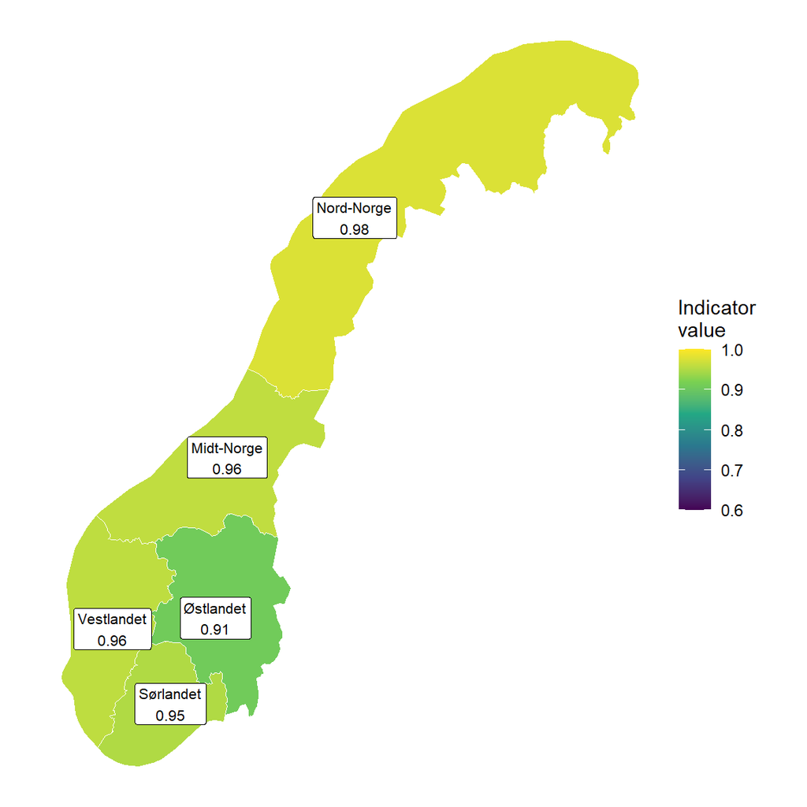

Figure 1: Indicator values per region

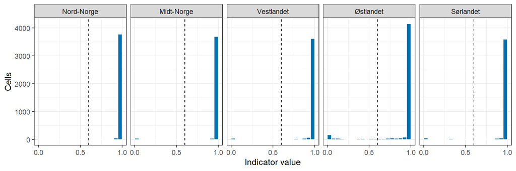

Figure 2: Distribution of cell values per region. The dashed line is 0.6.

## 11. Export file

The results are written by the code below and converted to the ecosystemCondition platform format by `R/export_deliverables.R`.

```r
# ===========================================================
# STAGE 14: Export.
# Polygon-level, grid-level (if computed) and regional-level wetland
# indicator tables. Suffixed "_OpenSource" throughout so outputs never
# collide with the gated-original pipeline's own exports.
# ===========================================================

vaatmarkIndexPolySpat %>%
  mutate(id = `system:index`, vegZn = vegClimZoneLab) %>%
  dplyr::select(-`system:index`, -vegClimZoneLab, -any_of("elevation")) %>%
  st_write(file.path(results_dir, paste0("VAAT-GJEN-01_wetland_index", out_suffix, ".shp")), delete_dsn = TRUE, quiet = TRUE)

vaatmarkIndexPolySpat %>%
  st_drop_geometry() %>%
  write_csv(file.path(results_dir, paste0("VAAT-GJEN-01_wetland_index", out_suffix, ".csv")))

if (!is.null(vaatmarkIndexGrid)) {
  vaatmarkIndexGrid %>%
    st_write(file.path(results_dir, paste0("VAAT-GJEN-01_wetland_index_grid", out_suffix, ".shp")), delete_dsn = TRUE, quiet = TRUE)
}

vaatmarkIndexRegion %>%
  st_write(file.path(results_dir, paste0("VAAT-GJEN-01_wetland_index_region", out_suffix, ".shp")), delete_dsn = TRUE, quiet = TRUE)

cat("Done. Open-source wetland indicator exported to:\n",
    " - ", file.path(results_dir, paste0("VAAT-GJEN-01_wetland_index", out_suffix, ".shp")), "\n",
    " - ", file.path(results_dir, paste0("VAAT-GJEN-01_wetland_index", out_suffix, ".csv")), "\n",
    " - ", file.path(results_dir, paste0("VAAT-GJEN-01_wetland_index_region", out_suffix, ".shp")), "\n", sep = "")
```

## 12. Author contributions

**CRediT statement**

- Software (code development): JACB, LK
- Validation (assessment): JACB, LK
- Writing of the project report: BS, JACB

BS: Bendik Sivertsen. JACB: Jesus Adrian Chimal-Ballesteros. LK: Lasse Keetz.

AI tools: Claude (Anthropic) was used for code development and review, for running and checking analyses, and for drafting this document. The use is described in the repository README.

**TipSession Info**